# PerrinetEtAl12neurocomp-intro slides

```python
HTML("""
<h1 class="title">Course on Computational Neuroscience</h1>
<h2>PhD program, Marseille</h2>
<h1> December 7th & 8th, 2015</h1>
<img src="figures/troislogos.png" width=61%/>
""")
```

Course on Computational Neuroscience

PhD program, Marseille

December 7th & 8th, 2015

[figure not shown]

- Alessandro Torcini, INS, INMED & CPT
- Demian Battaglia, INS
- Laurent Perrinet, INT
- Wahiba Taouali, INMED

## *Acknowledgements*:

- PhD program: Anna Montagnini, Frédéric Chavane, Nadia Pittet, INT, Marseille

ⓦ https://invibe.net/LaurentPerrinet/Presentations/2015-12-08_cours-NeuroComp

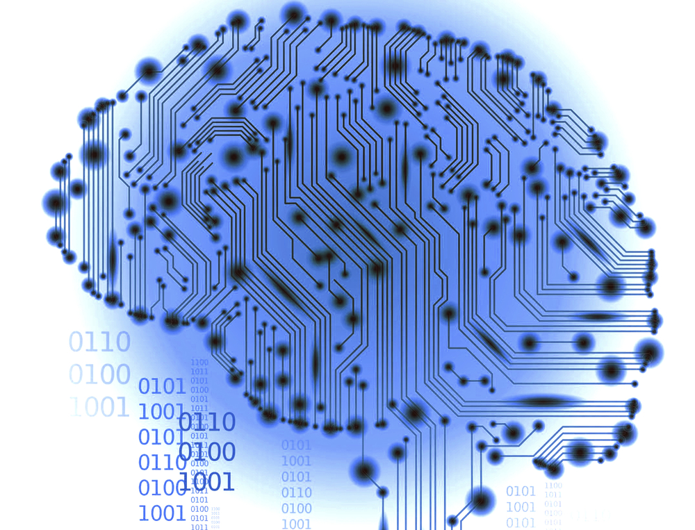

```python
#Image('http://static1.squarespace.com/static/55249fa2e4b004d7b9c37cf8/t/553d629be4b0810e9e82b01f/1430086332477/Neural.jpg', height=height, embed=True)
Image('figures/Neural.jpg', height=height, embed=True)
# http://www.mth.kcl.ac.uk/research/cns/brain.gif
# http://www.nbb.cornell.edu/Courses/image/Bionb3300%20Linster.jpg
```

# Computational Neuroscience

- **A branch of neuroscience which uses mathematical and computer models to understand how the brain works, that is, the principles of computation and representation and their neural implementation.**
- Aims:
  - *what?* description: unify data in a single framework.
  - *how?* understand underlying mechanisms.
  - *why?* understand principles underlying functions (optimality for eg) ⇢ make predictions / guide experiments. better data analysis.

[figure not shown]

```python
#Image('https://www0.maths.ox.ac.uk/files/imce/u896/homer_0.jpg', height=height, embed=True)
Image('figures/homer_0.jpg', height=height, embed=True)
```

# Some history

```python
HTML("""
<img src="figures/levels.png" height=1200 />
What is computational neuroscience?  Patricia S. Churchland, Christof Koch, Terrence J. Sejnowski. in Computational Neuroscience pp.46-55. Edited by Eric L. Schwartz. 1993. MIT Press
""")
#Image('figures/levels.png', height=height, embed=True)
```

[figure not shown]

What is computational neuroscience? Patricia S. Churchland, Christof Koch, Terrence J. Sejnowski. in Computational Neuroscience pp.46-55. Edited by Eric L. Schwartz. 1993. MIT Press

[figure not shown]

```python
#Image('http://www.gatsby.ucl.ac.uk/~Dayan/book/cover.gif', height=height, embed=True)
#Image('http://ecx.images-amazon.com/images/I/4127RGJX8NL._SY344_BO1,204,203,200_.jpg', height=height, embed=True)
Image('figures/4127RGJX8NL._SY344_BO1,204,203,200_.jpg', height=height, embed=True)
```

```python
#Image('http://www.paris-neuroscience.fr/sites/paris-neuroscience.fr/files/cns2013_poster.jpg', height=height, embed=True)
Image('figures/cns2013_poster.jpg', height=height, embed=True)
```

# Major topics in Computational Neuroscience

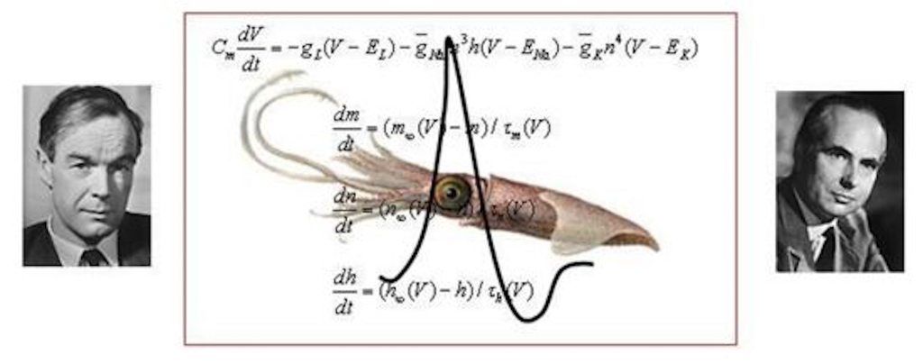

```python
Image('figures/computation-02-00047-ag_bigger.jpg', height=height, embed=True)
```

[figure not shown]

```python
#Image('https://dipanjanr.files.wordpress.com/2015/04/figure11.jpg', height=height, embed=True)
Image('figures/figure11.jpg', height=height, embed=True)
#Image('https://dipanjanr.files.wordpress.com/2015/04/rp_fig2-copy-page-001-1.jpg', height=height, embed=True)
```

[figure not shown]

```python
#Image('https://upload.wikimedia.org/wikipedia/en/f/ff/Monkey_using_a_robotic_arm.jpg', height=height, embed=True)
#Monkey operating a robotic arm with brain–computer interfacing (Schwartz lab, University of Pittsburgh)
#Image('http://www.nature.com/nrn/journal/v15/n5/images_article/nrn3724-f1.jpg', height=height, embed=True)
Image('figures/nrn3724-f1.jpg', height=height, embed=True)
```

# The program

See https://invibe.net/LaurentPerrinet/Presentations/2015-12-08_cours-NeuroComp

# Day 1 : 2015-12-07 : Computational Neuroscience

- 09:15-09:45 = [An introduction to the field of Computational Neuroscience](https://laurentperrinet.github.io/sciblog/files/2015-12-08_cours_neurocomp/PerrinetEtAl12neurocomp-intro.slides.html) (LP)
- 09:45-12:30 = Introduction to modeling single neurons: the Hodgkin-Huxley model (AT)
- 14:00-15:30 = An introduction to neural masses: modeling assemblies of neurons up to capturing resting state dynamics in a mean-field model - presentation of the Virtual Brain software (DB)
- 16:00-17:00 = A concrete application of modeling neural masses: the epileptor, or "From mathematical entomology to the virtual epileptic patient" (DB)

# Day 2 : 2015-12-08 : Information theory / statistics of decoding

- 09:00-10:30 = An overview on "What is encoding?" "What is decoding?": formalization of the notion of information in neural activity (DB)
- 11:00-12:30 = Live information! From sharing information to transferring information (and a glimpse into the zoo of higher-order friends) (DB)
- 14:00-17:30 = [Decoding of feature selectivity in neural activity](https://laurentperrinet.github.io/sciblog/files/2015-12-08_cours_neurocomp/PerrinetTaouali12neurocomp.slides.html): [Concrete applications in visual data](https://laurentperrinet.github.io/sciblog/files/2015-12-08_cours_neurocomp/TaoualiPerrinet12neurocomp.slides.html) (WT & LP).